# An empirical example: *Rhynoclemmys* data.

Daniel R. Miranda-Esquivel

2020 - 10 - 13

# An empirical example: *Rhynoclemmys* data.

We read the data, distribution and trees.

```r
options(warn=-1)
suppressMessages(library(ggtree))
#~ library(ape)
suppressMessages(library(blepd))
library(ggplot2)
#~ library(ggtree)



## read distributional data

setwd("../data/")

csvFile <- dir(pattern=".csv")


distribution <-          as.matrix(read.table(csvFile,
                                  stringsAsFactors=FALSE,
                                  header=TRUE,
                                  row.names=1,
                                  sep=",")
                          )

##qplot(distribution)



## read trees

treeFiles <- dir(pattern=".tre")

treeFiles
```

```
## [1] "RhinoMoleLike.tre" "RhinoTELike.tre"
```

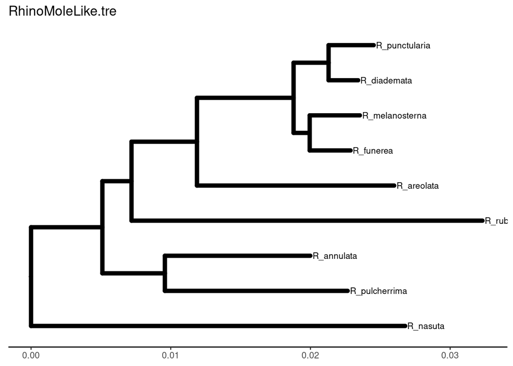

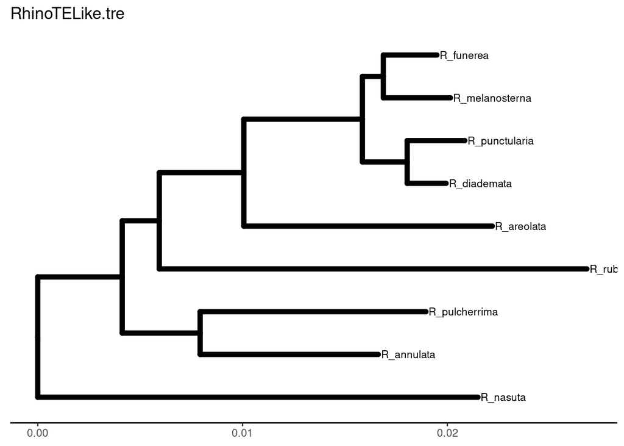

```r
RhinoclemmysData <- list()

RhinoclemmysData$distribution <- distribution

RhinoclemmysData$trees  <-    lapply(treeFiles,FUN=read.tree)


distXY <- matrix2XY(distribution)



## plotting

## the trees


par(mfrow=c(2,1))

for( numero in 1:length(treeFiles)){

plotTree <-  ggtree(RhinoclemmysData$trees[[numero]], ladderize=TRUE,
                    color="black", size=2, linetype="solid") +
             geom_tiplab(size=3, color="black") +
             theme_tree2() +
             ggtitle(treeFiles[numero])


##
print(plotTree)

}
```

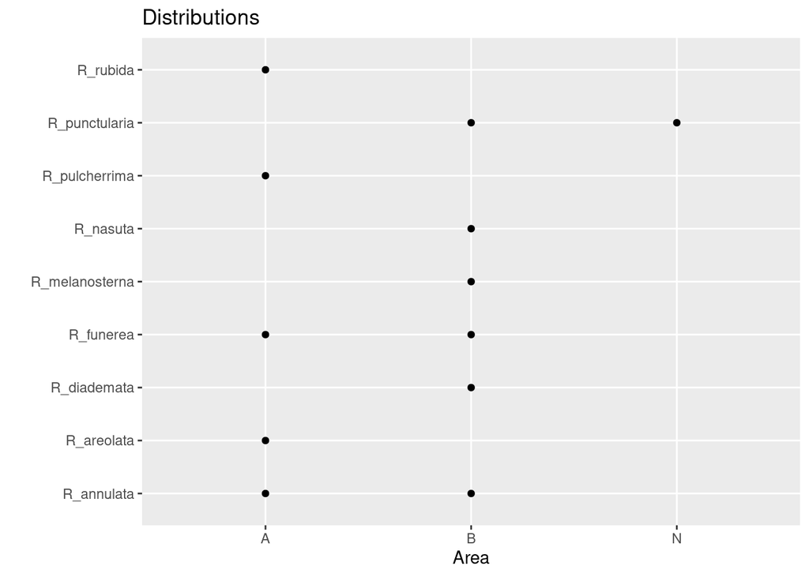

```r
#~ Alternatively, we can plot the trees using ape

#~ for(treeNumber in 1:length(treeFiles)){
#~
#~        plot.phylo(RhinoclemmysData$trees[[treeNumber]],
#~                   main=treeFiles[numero])
#~
#~    }





## the distribution


par(mfrow=c(1,1))

plotDistrib <-ggplot(distXY,
               aes(x= Area, y=Terminal), size =11) +
              geom_point() +
               labs(title = "Distributions",
                    y = "",
                    x = "Area")

##
print(plotDistrib)
```

```r
##cowplot::plot_grid(plotTree, plotDistrib, ncol=2)

# Using faceplot


#~ p2 <- facet_plot(plotTree, panel="dot",
#~                  data=distXY,
#~                  geom=geom_point(),
#~                  mapping=aes(x= distXY$Area,y=distXY$Terminal),
#~                  size =11, color='red3')


#~ print(p2)

##dev.off()
```

These two trees correspond to different data sources Molecular vs TotalEvidence data, and we want to test whether the data used will have any effect in the areas chosen, or if the area is selected given the terminal(s) branch length.

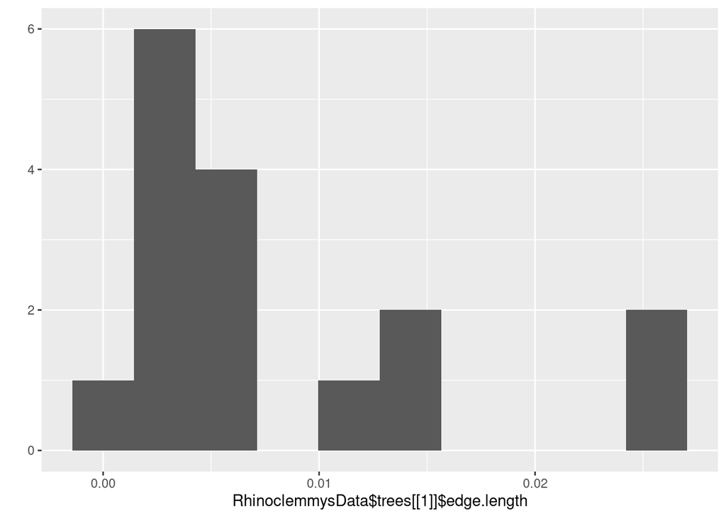

```r
par(mfrow=c(2,1))

qplot(RhinoclemmysData$trees[[1]]$edge.length,bins=10,title=treeFiles[1])
```

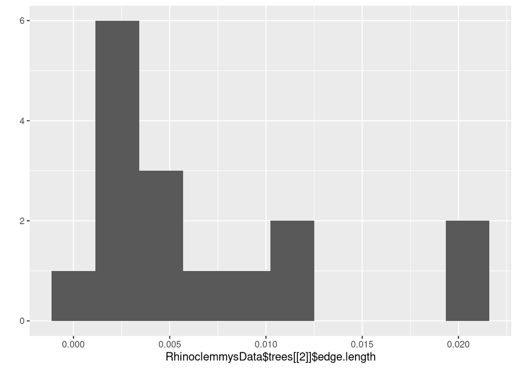

```r
qplot(RhinoclemmysData$trees[[2]]$edge.length,bins=10,title=treeFiles[2])
```

```r
###dev.off()
```

Fist we calculate the PD value for each tree, we save the values as a table and later we convert the table to a matrix:

```r
RhinoclemmysData$tablePD <- lapply(RhinoclemmysData$trees,
                                   FUN=PDindex,
                                   distribution=RhinoclemmysData$distribution,
                                   root=TRUE)



RhinoclemmysData$matrixPD <- as.data.frame(
                                  matrix(
                                      unlist(RhinoclemmysData$tablePD),
                                      nrow= length(treeFiles),
                                      byrow=TRUE))


RhinoclemmysData$tablePDPercentage <- lapply(RhinoclemmysData$trees,
                                             FUN=PDindex,
                                             distribution=RhinoclemmysData$distribution,
                                             percentual=TRUE,
                                             root=TRUE)

RhinoclemmysData$matrixPDPercentage <- as.data.frame(
                                          matrix(
                                              unlist(RhinoclemmysData$tablePDPercentage),
                                              nrow= length(treeFiles),
                                              byrow=TRUE))
```

Now we test the efect of branch length swapping, first for terminal branch lengths.

```r
for( numero in 1:length(treeFiles)){

    for(modelo in c("simpleswap","allswap","uniform")){

        val <- swapBL(RhinoclemmysData$trees[[numero]],distribution,
               model=modelo
               )

         cat("\nTree=",treeFiles[numero],"\tModel=",modelo,"\n")
        print.blepd(val)
         cat("\n\n\n")
    }

}
```

```
## model to test simpleswap reps 100
##
## Tree= RhinoMoleLike.tre  Model= simpleswap
##
## BestInitial:A    Selected:     AreaSelected Freq
## 1            A   63
## 2            B   37
##
##
##
## model to test allswap reps 100
##
## Tree= RhinoMoleLike.tre  Model= allswap
##
## BestInitial:A    Selected:     AreaSelected Freq
## 1            A   32
## 2            B   68
##
##
##
## model to test uniform reps 100
##
## Tree= RhinoMoleLike.tre  Model= uniform
##
## BestInitial:A    Selected:     AreaSelected Freq
## 1            A   18
## 2            B   82
##
##
##
## model to test simpleswap reps 100
##
## Tree= RhinoTELike.tre    Model= simpleswap
##
## BestInitial:A    Selected:     AreaSelected Freq
## 1            A   80
## 2            B   20
##
##
##
## model to test allswap reps 100
##
## Tree= RhinoTELike.tre    Model= allswap
##
## BestInitial:A    Selected:     AreaSelected Freq
## 1            A   29
## 2            B   71
##
##
##
## model to test uniform reps 100
##
## Tree= RhinoTELike.tre    Model= uniform
##
## BestInitial:A    Selected:     AreaSelected Freq
## 1            A   18
## 2            B   82
```

For both trees, the terminal branch length is critical in the decision taken, if we swap all terminal branch lengths (= *allswap*) or if we replce them with a uniform distribution (*uniform*), the area selected change from A to B.

As the terminal branch lengths are distributed unequally, we might suspect that the resultds depeds heavily on the longest branches that inhabit the area A.

```r
## Trsting if we reduce the brach lenght form the actualsise to 0.0 using evalTerminal {lower}

testEvalTerminalALL <- evalTerminal(RhinoclemmysData$trees[[1]],distribution,tipToEval = "all",approach = "lower")
```

```
##
## Terminal: R_nasuta, has NO effect on branch length == 0 or Max
## Terminal: R_pulcherrima, has NO effect on branch length == 0 or Max
## Terminal: R_annulata, has NO effect on branch length == 0 or Max
## Terminal: R_funerea, has NO effect on branch length == 0 or Max
## Terminal: R_melanosterna, has NO effect on branch length == 0 or Max
## Terminal: R_diademata, has NO effect on branch length == 0 or Max
## Terminal: R_punctularia, has NO effect on branch length == 0 or Max
```

```r
print.multiBlepd(testEvalTerminalALL)
```

```
##
## Delta (%)    Terminal    Initial Selected    Evaluating lower
## 0     R_nasuta   A   A
## 0     R_pulcherrima  A   A
## 0     R_annulata     A   A
## 0.0109    R_rubida   A   B
## -1e-04    R_areolata     A   B
## 0     R_funerea  A   A
## 0     R_melanosterna     A   A
## 0     R_diademata    A   A
## 0     R_punctularia  A   A
```

```r
## Trsting if we increase the brach lenght form the actualsise to the sum of all brach length  using evalTerminal {upper}


testEvalTerminalALL <- evalTerminal(RhinoclemmysData$trees[[1]],distribution,tipToEval = "all",approach = "upper")
```

```
##
## Terminal: R_pulcherrima, has NO effect on branch length == 0 or Max
## Terminal: R_annulata, has NO effect on branch length == 0 or Max
## Terminal: R_rubida, has NO effect on branch length == 0 or Max
## Terminal: R_areolata, has NO effect on branch length == 0 or Max
## Terminal: R_funerea, has NO effect on branch length == 0 or Max
```

```r
print.multiBlepd(testEvalTerminalALL)
```

```
##
## Delta (%)    Terminal    Initial Selected    Evaluating upper
## 52.9073   R_nasuta   A   B
## 0     R_pulcherrima  A   A
## 0     R_annulata     A   A
## 0     R_rubida   A   A
## 0     R_areolata     A   A
## 0     R_funerea  A   A
## 394.139   R_melanosterna     A   B
## 676.815   R_diademata    A   B
## 444.594   R_punctularia  A   B
```

The area selected depends heavily in the branch length of *R.* *aerolata* and *R.* *rubida*, if the brach length is just a little shorter, the area selected will change from area A to area B.